# Merge AMOBIO and ASPE data

We merge the AMOBIO and ASPE datasets. AMOBIO contains information about environmental stressors, and in particular, nutrients and dam impacts. ASPE contains information about local food web structure. By merging these two datasets we can relate food web structure to environmental stressors.

## Todo

- Check join between AMOBIO and ASPE data
- Select variable of interest
- Function to join AMOBIO and ASPE data from files
- Improve figure theme
- Make a table of the number of points (once merged), and NAs per environmental variables
- Check colinarity between variables
- Check for extreme values in environmental variables (in particular, nutrients)
- Add regulatory nutrient thresholds
- Make an synthetic variabel for chemical compounds (if relevant) that would be a proxy of eutrophication
- Update and improve spatial visualisation of structure metrics
- Update and improve statistical model

## Setup

```r
library(renv)
renv::load()
library(targets)
library(here)
tar_config_set(
  store = here::here("_targets")
)
library(ggplot2)
library(hrbrthemes)
library(dplyr)
library(sf)
devtools::load_all()
riversea::nice_theme()
```

Here is the merged dataframe, which contains information food web structure and environmental stressors.

```r
data <- tar_read(amobio_aspe_data)
str(data)
```

```
sf [8,372 × 31] (S3: sf/tbl_df/tbl/data.frame)
 $ node_id                : int [1:8372] 1471 2072 2958 2958 4891 4891 5168 5168 7629 7629 ...
 $ elevation              : num [1:8372] 401 1195 1730 1730 248 ...
 $ sandre_code            : chr [1:8372] "06166990" "06169880" "06175400" "06175400" ...
 $ date                   : Date[1:8372], format: "2019-07-19" "2020-06-26" ...
 $ dam_distance_downstream: num [1:8372] 16194 23251 5020 5020 5429 ...
 $ dam_distance_upstream  : num [1:8372] NA 17219 NA NA 39653 ...
 $ barrier_upstream       : num [1:8372] 1.32 2.63 0 0 2.14 ...
 $ barrier_downstream     : num [1:8372] 1.36 2.68 5.34 5.34 2.7 ...
 $ total_phosphorus       : num [1:8372] 0.0111 0.068 NA NA 0.0467 ...
 $ phosphate              : num [1:8372] 0.039 0.168 NA NA 0.098 ...
 $ nitrate                : num [1:8372] 0.91 1.44 NA NA 1.02 ...
 $ nitrite                : num [1:8372] 0.005 0.0075 NA NA 0.035 ...
 $ ammonium               : num [1:8372] 0.0395 0.0125 NA NA 0.0742 ...
 $ kjeldahl_nitrogen      : num [1:8372] 0.25 0.305 NA NA 0.5 ...
 $ operation_id           : chr [1:8372] "81700" "84804" "82864" "85508" ...
 $ foodweb                :List of 8372
  ..$ : num [1:15, 1:15] 0 0 0 0 0 0 0 0 0 0 ...
  .. ..- attr(*, "dimnames")=List of 2
  .. .. ..$ : chr [1:15] "Anguilla anguilla_1" "Anguilla anguilla_2" "Anguilla anguilla_3" "Salmo trutta_1" ...
  .. .. ..$ : chr [1:15] "Anguilla anguilla_1" "Anguilla anguilla_2" "Anguilla anguilla_3" "Salmo trutta_1" ...
  ..$ : num [1:13, 1:13] 0 0 0 0 0 0 0 0 1 1 ...
  .. ..- attr(*, "dimnames")=List of 2
  .. .. ..$ : chr [1:13] "Phoxinus phoxinus_1" "Salmo trutta_1" "Salmo trutta_2" "biofilm" ...
  .. .. ..$ : chr [1:13] "Phoxinus phoxinus_1" "Salmo trutta_1" "Salmo trutta_2" "biofilm" ...
  ..$ : num [1:17, 1:17] 0 0 0 0 0 0 0 0 0 0 ...
  .. ..- attr(*, "dimnames")=List of 2
  .. .. ..$ : chr [1:17] "Alburnus alburnus_1" "Alburnus alburnus_2" "Cottus gobio_2" "Gobio gobio_1" ...
  .. .. ..$ : chr [1:17] "Alburnus alburnus_1" "Alburnus alburnus_2" "Cottus gobio_2" "Gobio gobio_1" ...
  ..$ : num [1:15, 1:15] 0 0 0 0 0 1 0 0 0 0 ...
  .. ..- attr(*, "dimnames")=List of 2
  .. .. ..$ : chr [1:15] "Squalius cephalus_1" "Squalius cephalus_2" "Phoxinus phoxinus_1" "Salmo trutta_1" ...
  .. .. ..$ : chr [1:15] "Squalius cephalus_1" "Squalius cephalus_2" "Phoxinus phoxinus_1" "Salmo trutta_1" ...
  ..$ : num [1:24, 1:24] 0 0 0 0 0 0 0 0 0 0 ...
  .. ..- attr(*, "dimnames")=List of 2
  .. .. ..$ : chr [1:24] "Barbatula barbatula_1" "Gobio gobio_1" "Rutilus rutilus_2" "Rutilus rutilus_3" ...
  .. .. ..$ : chr [1:24] "Barbatula barbatula_1" "Gobio gobio_1" "Rutilus rutilus_2" "Rutilus rutilus_3" ...
  ..$ : num [1:21, 1:21] 0 0 0 0 0 0 0 0 0 0 ...
  .. ..- attr(*, "dimnames")=List of 2
  .. .. ..$ : chr [1:21] "Gobio gobio_1" "Squalius cephalus_1" "Leuciscus leuciscus_1" "Leuciscus leuciscus_2" ...
```

[output cut: 377 more lines]

```
 $ trophic_length         : num [1:8372] 4.92 4.56 4.62 4.62 4.84 ...
 $ trophic_breadth_q90    : num [1:8372] 0.373 0.446 0.341 0.467 0.267 ...
 $ trophic_breadth_median : num [1:8372] 0.2 0.231 0.176 0.267 0.146 ...
 $ frac_piscivorous       : num [1:8372] 0.6 0.333 0.143 0.4 0.143 ...
 $ diet_overlap           : num [1:8372] 0.249 0.27 0.272 0.257 0.315 ...
 $ year                   : num [1:8372] 2019 2020 2019 2020 2010 ...
 $ month                  : num [1:8372] 7 6 8 9 9 9 9 8 9 8 ...
 $ longitude              : num [1:8372] 2.61 2.15 2.07 2.07 2.48 ...
 $ latitude               : num [1:8372] 42.5 42.5 42.6 42.6 42.6 ...
 $ survey                 : chr [1:8372] "river" "river" "river" "river" ...
 $ salinity               : num [1:8372] NA NA NA NA NA NA NA NA NA NA ...
 $ geometry               :sfc_POINT of length 8372; first list element:  'XY' num [1:2] 667653 6152246
 - attr(*, "sf_column")= chr "geometry"
 - attr(*, "agr")= Factor w/ 3 levels "constant","aggregate",..: NA NA NA NA NA NA NA NA NA NA ...
  ..- attr(*, "names")= chr [1:30] "node_id" "elevation" "sandre_code" "date" ...
```

## Data completeness

### Missing values

The merged dataset has 8372 points. Here is the number and share of missing values for each environmental variable, along with the range of observed values.

```r
riversea::summarise_env_na(data) |>
  knitr::kable(digits = 2)
```

| variable | n | n_na | pct_na | min | median | max |
| --- | --- | --- | --- | --- | --- | --- |
| elevation | 8372 | 0 | 0.0 | 0.00 | 127.90 | 1801.94 |
| dam_distance_upstream | 8372 | 3376 | 40.3 | 0.00 | 12640.72 | 347269.50 |
| dam_distance_downstream | 8372 | 407 | 4.9 | 12.44 | 17371.42 | 1086201.21 |
| barrier_downstream | 8372 | 0 | 0.0 | 0.00 | 1.32 | 25.17 |
| barrier_upstream | 8372 | 0 | 0.0 | 0.00 | 1.04 | 25.10 |
| total_phosphorus | 8372 | 2870 | 34.3 | 0.00 | 0.07 | 3.98 |
| phosphate | 8372 | 2872 | 34.3 | 0.00 | 0.10 | 12.03 |
| ammonium | 8372 | 2871 | 34.3 | 0.00 | 0.04 | 6.50 |
| nitrite | 8372 | 2878 | 34.4 | 0.00 | 0.05 | 4.35 |
| nitrate | 8372 | 2862 | 34.2 | 0.25 | 14.36 | 79.95 |
| kjeldahl_nitrogen | 8372 | 2882 | 34.4 | 0.08 | 0.51 | 6.47 |

### Temporal coverage

Here is the the number of observation (removing NAs) per variable, by year.

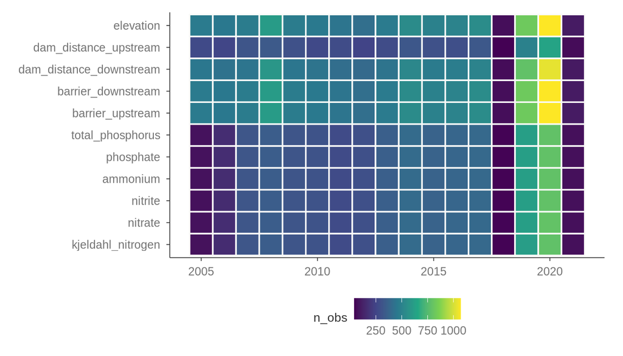

```r
riversea::plot_env_temporal_coverage(data)
```

## Collinearity between environmental variables

Before fitting statistical models, we check whether environmental variables are correlated with each other, which would make it hard to separate their individual effects. We subsample points to keep the pair plot readable and fast to render.

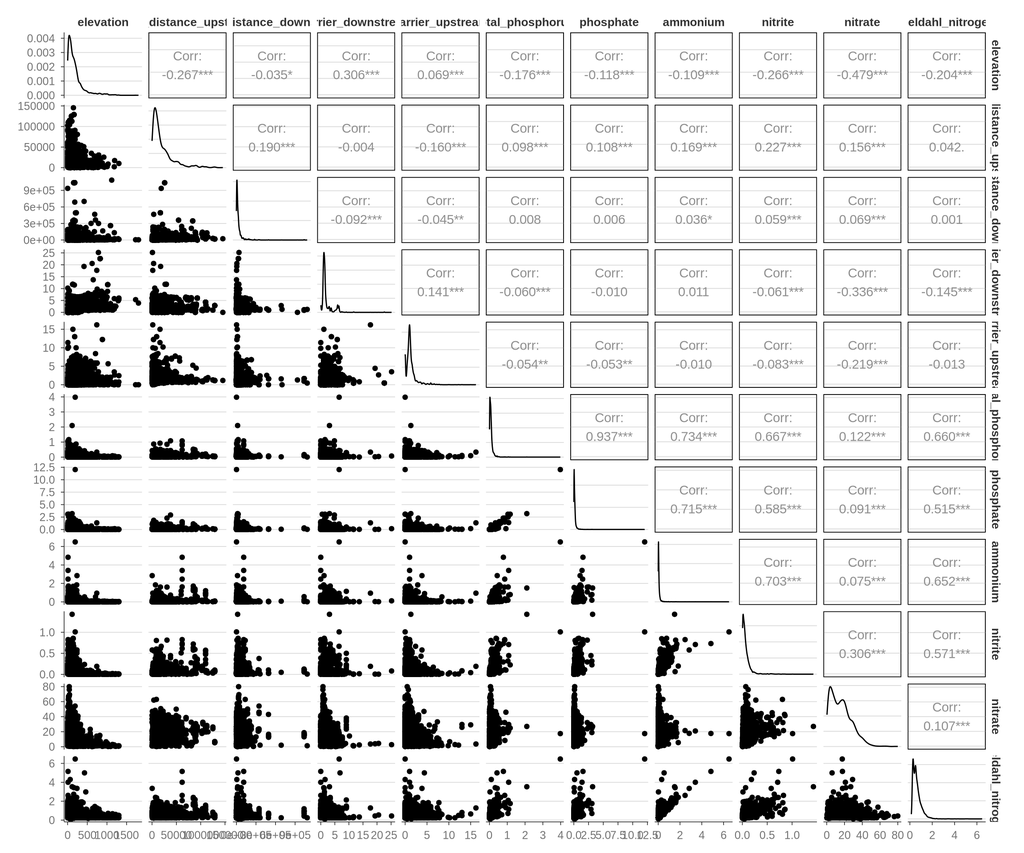

```r
env_vars <- setdiff(names(riversea::rename_amobio()), c("date", "sandre_code"))

data |>
  st_drop_geometry() |>
  select(all_of(env_vars)) |>
  slice_sample(n = 5000) |>
  GGally::ggpairs(columns = env_vars)
```

## Extreme values

We check for extreme values in the nutrient variables (phosphorus and nitrogen derivatives). Values are flagged as extreme using Tukey’s fences (below `Q1 - 1.5 * IQR` or above `Q3 + 1.5 * IQR`), computed on the log10 scale.

```r
riversea::summarise_env_outliers(data) |>
  knitr::kable(digits = 3)
```

| variable | n | n_outlier | pct_outlier | fence_low | fence_high | min | max |
| --- | --- | --- | --- | --- | --- | --- | --- |
| total_phosphorus | 5502 | 114 | 2.07 | 0.006 | 0.649 | 0.002 | 3.980 |
| phosphate | 5500 | 51 | 0.93 | 0.007 | 1.374 | 0.005 | 12.033 |
| ammonium | 5501 | 116 | 2.11 | 0.004 | 0.503 | 0.005 | 6.497 |
| nitrite | 5494 | 7 | 0.13 | 0.002 | 0.824 | 0.005 | 4.347 |
| nitrate | 5510 | 74 | 1.34 | 0.871 | 165.241 | 0.250 | 79.947 |
| kjeldahl_nitrogen | 5490 | 19 | 0.35 | 0.101 | 2.606 | 0.075 | 6.467 |

We have also extracted threshold data to have an idea when the nutrient concentration is harmful for living organisms. The data is taken from [here](https://rhin-meuse.eaufrance.fr/IMG/pdf/grilles-seq-eau-v2.pdf).

```r
seq_eau_file <- here("data", "river", "seq_eau_nutrient_thresholds.csv")
data_seq_eau <- readr::read_csv(seq_eau_file)
data_seq_eau |>
  knitr::kable(digits = 3)
```

| variable | seq_eau_parameter | unit | tres_bon_max | bon_max | moyen_max | mediocre_max | mauvais_min |
| --- | --- | --- | --- | --- | --- | --- | --- |
| total_phosphorus | Phosphore total (P) | mg/L P | 0.05 | 0.2 | 0.5 | 1 | 1 |
| phosphate | Orthophosphates (PO4 3-) | mg/L PO4 | 0.10 | 0.5 | 1.0 | 2 | 2 |
| ammonium | Ammonium (NH4+) | mg/L NH4 | 0.10 | 0.5 | 2.0 | 5 | 5 |
| nitrite | Nitrites (NO2-) | mg/L NO2 | 0.03 | 0.3 | 0.5 | 1 | 1 |
| nitrate | Nitrates (NO3-) | mg/L NO3 | 2.00 | 10.0 | 25.0 | 50 | 50 |
| kjeldahl_nitrogen | Azote Kjeldahl (NKJ) | mg/L N | 1.00 | 2.0 | 4.0 | 10 | 10 |

Next, we plot the distribution of the nutrient concentrations and overlay the threshold values corresponding to a “mauvais” water health state.

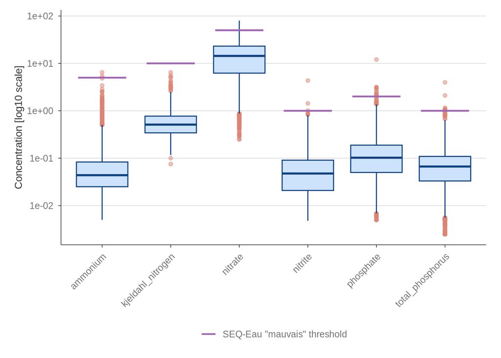

```r
plot_env_boxplot(data, thresholds = data_seq_eau)
```

## Map trophic structure

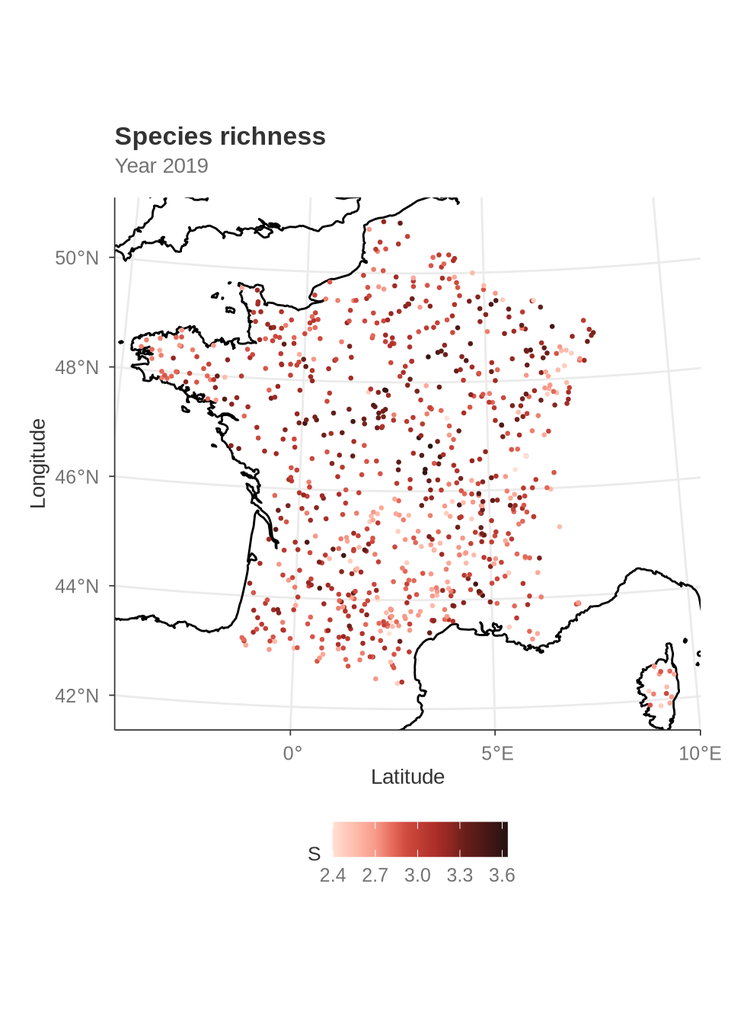

```r
plot_amobio_metric(
  data,
  "log_species_richness",
  year = 2019,
  title = "Species richness",
  subtitle = "Year 2019",
  legend = "S"
)
```

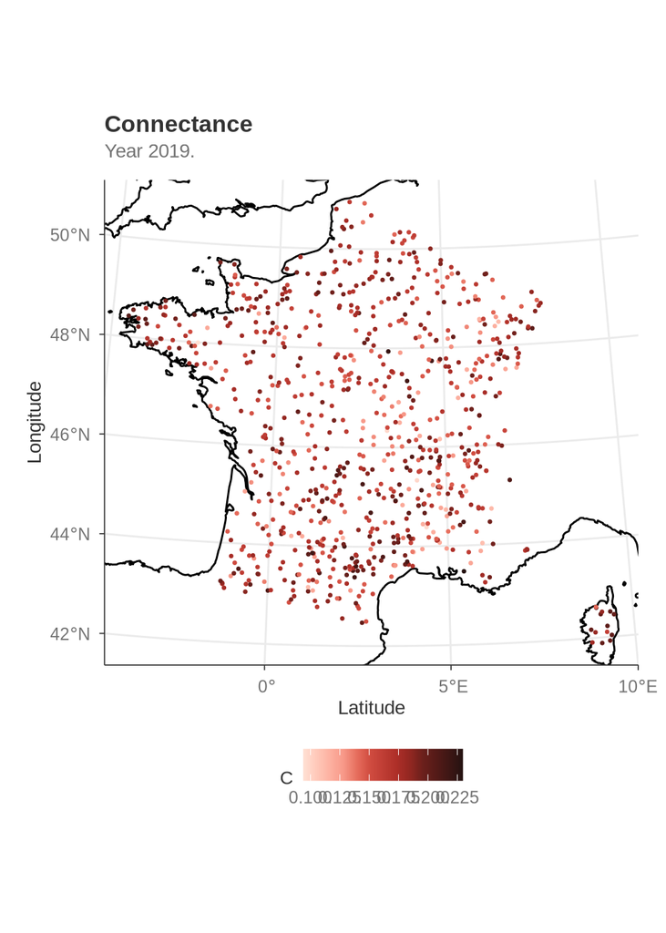

```r
plot_amobio_metric(
  data,
  "connectance",
  year = 2019,
  title = "Connectance",
  subtitle = "Year 2019.",
  legend = "C"
)
```

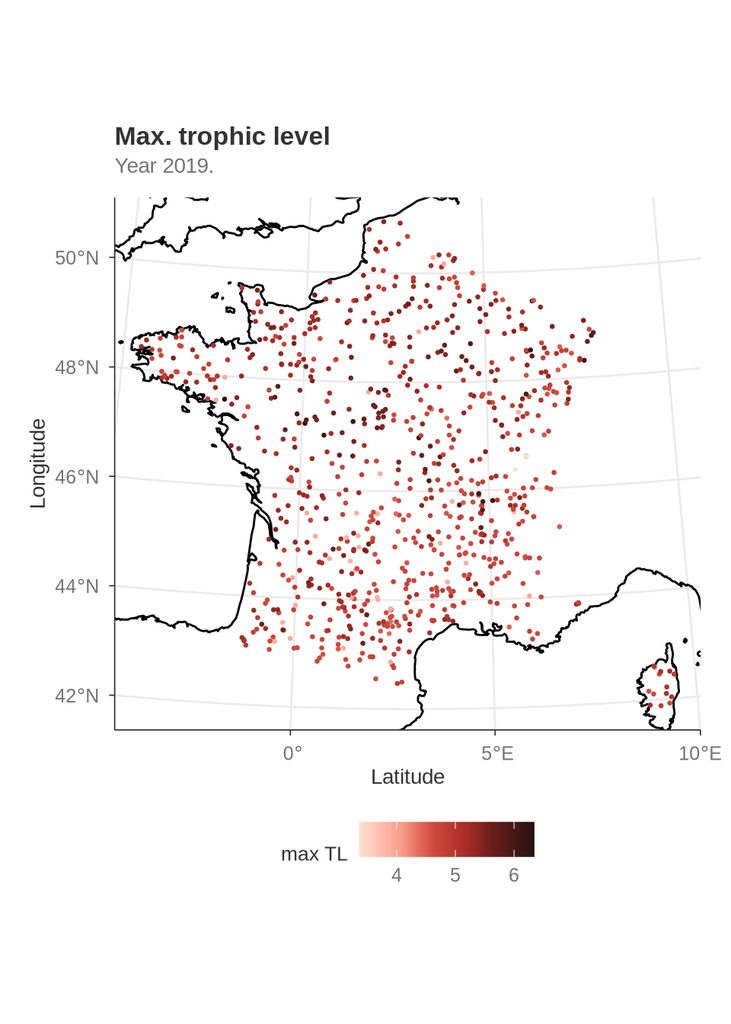

```r
plot_amobio_metric(
  data,
  "trophic_length",
  year = 2019,
  title = "Max. trophic level",
  subtitle = "Year 2019.",
  legend = "max TL"
)
```

## Link food web structure to environment

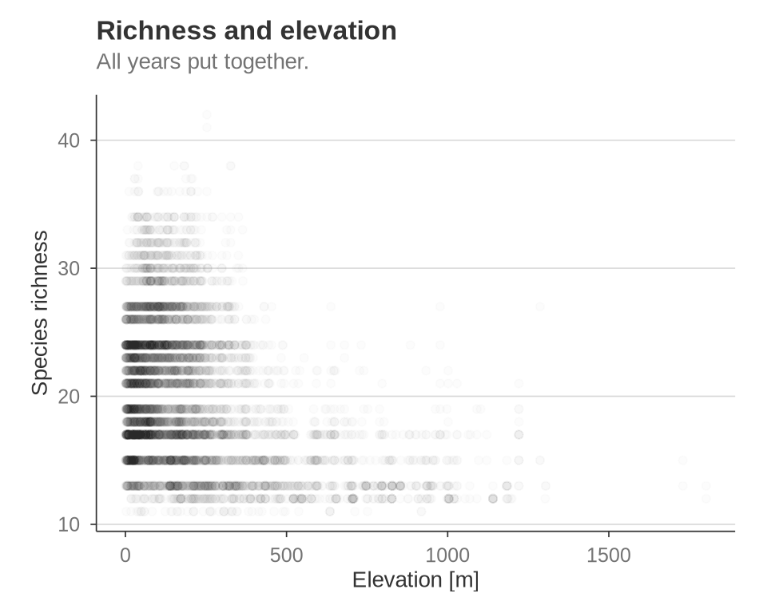

```r
data <- data |>
  mutate(S = as.integer(exp(log_species_richness)))

ggplot(data, aes(x = elevation, y = S)) +
  geom_point(alpha = 0.01) +
  labs(
    x = "Elevation [m]",
    y = "Species richness",
    title = "Richness and elevation",
    subtitle = "All years put together."
  )
```

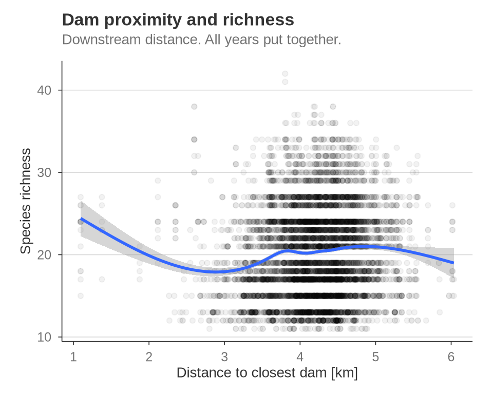

```r
ggplot(data, aes(x = log10(dam_distance_downstream), y = S)) +
  geom_point(alpha = 0.05) +
  geom_smooth() +
  labs(
    x = "Distance to closest dam [km]",
    y = "Species richness",
    title = "Dam proximity and richness",
    subtitle = "Downstream distance. All years put together."
  )
```

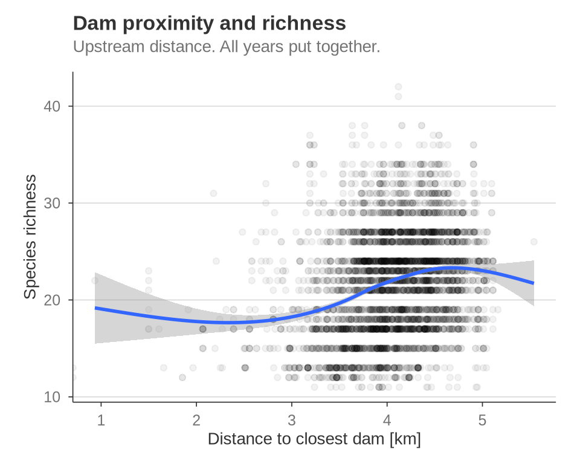

```r
ggplot(data, aes(x = log10(dam_distance_upstream), y = S)) +
  geom_point(alpha = 0.05) +
  geom_smooth() +
  labs(
    x = "Distance to closest dam [km]",
    y = "Species richness",
    title = "Dam proximity and richness",
    subtitle = "Upstream distance. All years put together."
  )
```

## Statistical models

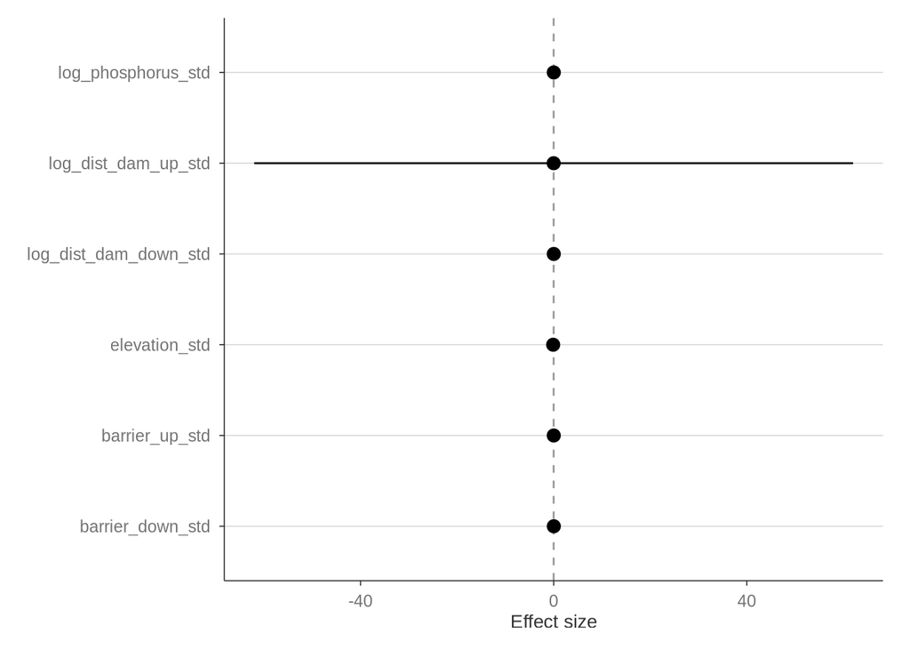

```r
library(INLA)

data_inla <- data |>
  st_drop_geometry() |>
  filter_out(dam_distance_downstream == 0) |>
  mutate(
    year = as.integer(lubridate::year(date)),
    site_id = as.integer(sandre_code),
    log_dist_dam_up_std = scale(log10(dam_distance_upstream)),
    log_dist_dam_down_std = scale(log10(dam_distance_downstream)),
    barrier_up_std = scale(barrier_upstream),
    barrier_down_std = scale(barrier_downstream),
    log_phosphorus_std = scale(log10(total_phosphorus)),
    elevation_std = scale(elevation)
  ) |>
  select(
    S,
    year,
    site_id,
    log_dist_dam_up_std,
    log_dist_dam_down_std,
    barrier_up_std,
    barrier_down_std,
    log_phosphorus_std,
    elevation_std
  )


m_S <- inla(
  S ~ log_dist_dam_up_std + log_dist_dam_down_std +
    barrier_up_std + barrier_down_std +
    log_phosphorus_std +
    elevation_std +
    f(site_id, model = "iid") +
    f(year, model = "iid"),
  family = "nbinomial",
  data = data_inla
)

extract_fixed <- function(model, model_name) {
  model$summary.fixed |>
    tibble::rownames_to_column("term") |>
    filter(term != "(Intercept)") |>
    mutate(model = model_name)
}

fixed <- extract_fixed(m_S, "Richness")

ggplot(fixed, aes(x = mean, y = term)) +
  geom_vline(xintercept = 0, linetype = "dashed", color = "grey60") +
  geom_linerange(aes(xmin = `0.025quant`, xmax = `0.975quant`),
    position = position_dodge(width = 0.5)
  ) +
  geom_point(aes(x = `0.5quant`),
    size = 3,
    position = position_dodge(width = 0.5)
  ) +
  labs(x = "Effect size", y = NULL, color = NULL) +
  theme(legend.position = "bottom")
```